# Prediction assignment writeup

Lukas

2024-02-23

This document aims at developing a statistical model for Human Activity Recognition or HAR. The prediction aims at evaluating how well a unilateral dumbbell bicep curl is performed. This [Weight Lifting Exercise data](http://web.archive.org/web/20161224072740/http:/groupware.les.inf.puc-rio.br/har) contains measurements on six male participants.

### Data acquisition

```r
#training data
download.file('https://d396qusza40orc.cloudfront.net/predmachlearn/pml-training.csv','training.csv')

#testing data
download.file('https://d396qusza40orc.cloudfront.net/predmachlearn/pml-testing.csv','testing.csv')
```

```r
training<-read.csv('training.csv')
testing<-read.csv('testing.csv')
```

### Exploratory data analysis on the training data set

We first want to assess the nature of the outcome variable we want to predict. In this instance, it concerns the *classe* variable in the dataset, that entails a scoring value, evaluated on a scale of **A**-**E**.

```r
kable(table(training$classe))
```

| Var1 | Freq |
| --- | --- |
| A | 5580 |
| B | 3797 |
| C | 3422 |
| D | 3216 |
| E | 3607 |

```r
str(training[,-c(1:7,160)],L = as.list(1:15),list.len=25)
```

```
'data.frame':   19622 obs. of  152 variables:
 $ roll_belt               : num  1.41 1.41 1.42 1.48 1.48 1.45 1.42 1.42 1.43 1.45 ...
 $ pitch_belt              : num  8.07 8.07 8.07 8.05 8.07 8.06 8.09 8.13 8.16 8.17 ...
 $ yaw_belt                : num  -94.4 -94.4 -94.4 -94.4 -94.4 -94.4 -94.4 -94.4 -94.4 -94.4 ...
 $ total_accel_belt        : int  3 3 3 3 3 3 3 3 3 3 ...
 $ kurtosis_roll_belt      : chr  "" "" "" "" ...
 $ kurtosis_picth_belt     : chr  "" "" "" "" ...
 $ kurtosis_yaw_belt       : chr  "" "" "" "" ...
 $ skewness_roll_belt      : chr  "" "" "" "" ...
 $ skewness_roll_belt.1    : chr  "" "" "" "" ...
 $ skewness_yaw_belt       : chr  "" "" "" "" ...
 $ max_roll_belt           : num  NA NA NA NA NA NA NA NA NA NA ...
 $ max_picth_belt          : int  NA NA NA NA NA NA NA NA NA NA ...
 $ max_yaw_belt            : chr  "" "" "" "" ...
 $ min_roll_belt           : num  NA NA NA NA NA NA NA NA NA NA ...
 $ min_pitch_belt          : int  NA NA NA NA NA NA NA NA NA NA ...
 $ min_yaw_belt            : chr  "" "" "" "" ...
 $ amplitude_roll_belt     : num  NA NA NA NA NA NA NA NA NA NA ...
 $ amplitude_pitch_belt    : int  NA NA NA NA NA NA NA NA NA NA ...
 $ amplitude_yaw_belt      : chr  "" "" "" "" ...
 $ var_total_accel_belt    : num  NA NA NA NA NA NA NA NA NA NA ...
 $ avg_roll_belt           : num  NA NA NA NA NA NA NA NA NA NA ...
 $ stddev_roll_belt        : num  NA NA NA NA NA NA NA NA NA NA ...
 $ var_roll_belt           : num  NA NA NA NA NA NA NA NA NA NA ...
 $ avg_pitch_belt          : num  NA NA NA NA NA NA NA NA NA NA ...
 $ stddev_pitch_belt       : num  NA NA NA NA NA NA NA NA NA NA ...
  [list output truncated]
```

```r
training$classe<-factor(training$classe)
training_GA<-select(training,starts_with(c('gyros','accel','classe')))
testing_GA<-select(testing,starts_with(c('gyros','accel','classe')))
```

The data set which we’ll use to train the prediction models coincide with the raw sensor data of the gyroscope and accelerometer measurements.

```r
str(training_GA)
```

```
'data.frame':   19622 obs. of  25 variables:
 $ gyros_belt_x    : num  0 0.02 0 0.02 0.02 0.02 0.02 0.02 0.02 0.03 ...
 $ gyros_belt_y    : num  0 0 0 0 0.02 0 0 0 0 0 ...
 $ gyros_belt_z    : num  -0.02 -0.02 -0.02 -0.03 -0.02 -0.02 -0.02 -0.02 -0.02 0 ...
 $ gyros_arm_x     : num  0 0.02 0.02 0.02 0 0.02 0 0.02 0.02 0.02 ...
 $ gyros_arm_y     : num  0 -0.02 -0.02 -0.03 -0.03 -0.03 -0.03 -0.02 -0.03 -0.03 ...
 $ gyros_arm_z     : num  -0.02 -0.02 -0.02 0.02 0 0 0 0 -0.02 -0.02 ...
 $ gyros_dumbbell_x: num  0 0 0 0 0 0 0 0 0 0 ...
 $ gyros_dumbbell_y: num  -0.02 -0.02 -0.02 -0.02 -0.02 -0.02 -0.02 -0.02 -0.02 -0.02 ...
 $ gyros_dumbbell_z: num  0 0 0 -0.02 0 0 0 0 0 0 ...
 $ gyros_forearm_x : num  0.03 0.02 0.03 0.02 0.02 0.02 0.02 0.02 0.03 0.02 ...
 $ gyros_forearm_y : num  0 0 -0.02 -0.02 0 -0.02 0 -0.02 0 0 ...
 $ gyros_forearm_z : num  -0.02 -0.02 0 0 -0.02 -0.03 -0.02 0 -0.02 -0.02 ...
 $ accel_belt_x    : int  -21 -22 -20 -22 -21 -21 -22 -22 -20 -21 ...
 $ accel_belt_y    : int  4 4 5 3 2 4 3 4 2 4 ...
 $ accel_belt_z    : int  22 22 23 21 24 21 21 21 24 22 ...
 $ accel_arm_x     : int  -288 -290 -289 -289 -289 -289 -289 -289 -288 -288 ...
 $ accel_arm_y     : int  109 110 110 111 111 111 111 111 109 110 ...
 $ accel_arm_z     : int  -123 -125 -126 -123 -123 -122 -125 -124 -122 -124 ...
 $ accel_dumbbell_x: int  -234 -233 -232 -232 -233 -234 -232 -234 -232 -235 ...
 $ accel_dumbbell_y: int  47 47 46 48 48 48 47 46 47 48 ...
 $ accel_dumbbell_z: int  -271 -269 -270 -269 -270 -269 -270 -272 -269 -270 ...
 $ accel_forearm_x : int  192 192 196 189 189 193 195 193 193 190 ...
 $ accel_forearm_y : int  203 203 204 206 206 203 205 205 204 205 ...
 $ accel_forearm_z : int  -215 -216 -213 -214 -214 -215 -215 -213 -214 -215 ...
 $ classe          : Factor w/ 5 levels "A","B","C","D",..: 1 1 1 1 1 1 1 1 1 1 ...
```

When plotting the pairs data for the first 6 variables, we can spot some sporadic correlation. The numeric values for the measurements are also quite over the place, which would benefit from some rescaling and centering (normalizing the values) in a preprocessing step, prior to the training of the model.

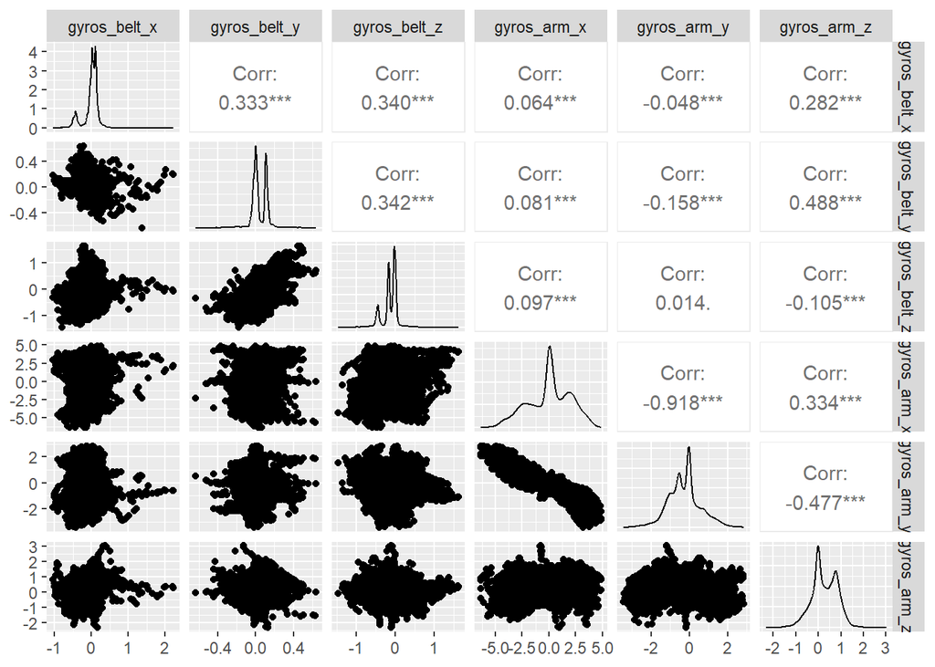

```r
ggpairs(training_GA,columns = 1:6)
```

We have access to gyroscope and accelerometer data on the arm, forearm, dumbbell and belt, for all three-dimensional axes of x, y and z. This amounts to 24 numeric measurement variables. This subset of data, further denoted as training_GA (**G**-gyroscope & **A**-accelerometer), will be subjected to a classification model to predict the *classe* outcome. The first model under scrutiny is a general Classification and Regression Tree in the **rpart** method. This model was chosen for its general ease of interpretation and visualization.

For cross validation, the default implementation of 10-fold cross validation was implemented, repeated 5 times. Therefore, in this case the training data was subset in 10 validation subsets. Each validation subset was evaluated with the other 9 subsets as training data. Tenfold is quite robust as it uses most of the training data and a rather small subset to validate. If we’d however opt for leave one out cross validation (LOOCV) we’d run into a massive increase in computation time, since we’d increase our cross validation steps from 10 to the amount of observations in our dataset (19622).

```r
rpart_GA_model<-train(classe~.,training_GA,
                      method='rpart',
                      preProcess=c('center','scale'),
                      trControl=trainControl(method='repeatedcv',repeats = 5))

confusionMatrix(predict(rpart_GA_model,training_GA),training_GA$classe)
```

```
Confusion Matrix and Statistics

          Reference
Prediction    A    B    C    D    E
         A 4394 2202 2405  816  976
         B   50  641   30   52  460
         C    0    0    0    0    0
         D 1127  938  985 2123  608
         E    9   16    2  225 1563

Overall Statistics

               Accuracy : 0.4445
                 95% CI : (0.4375, 0.4514)
    No Information Rate : 0.2844
    P-Value [Acc > NIR] : < 2.2e-16

                  Kappa : 0.2749

 Mcnemar's Test P-Value : < 2.2e-16

Statistics by Class:

                     Class: A Class: B Class: C Class: D Class: E
Sensitivity            0.7875  0.16882   0.0000   0.6601  0.43332
Specificity            0.5443  0.96259   1.0000   0.7770  0.98426
Pos Pred Value         0.4071  0.51987      NaN   0.3672  0.86116
Neg Pred Value         0.8657  0.82838   0.8256   0.9210  0.88521
Prevalence             0.2844  0.19351   0.1744   0.1639  0.18382
Detection Rate         0.2239  0.03267   0.0000   0.1082  0.07966
Detection Prevalence   0.5500  0.06284   0.0000   0.2946  0.09250
Balanced Accuracy      0.6659  0.56570   0.5000   0.7186  0.70879
```

The model can somewhat assign a performance classification of **A, D and E** for the Weight Lifting Exercise (WLE) fairly well, it can however not even remotely distinguish **B and C**, which results in an overall poor performance of just about 44% accuracy.

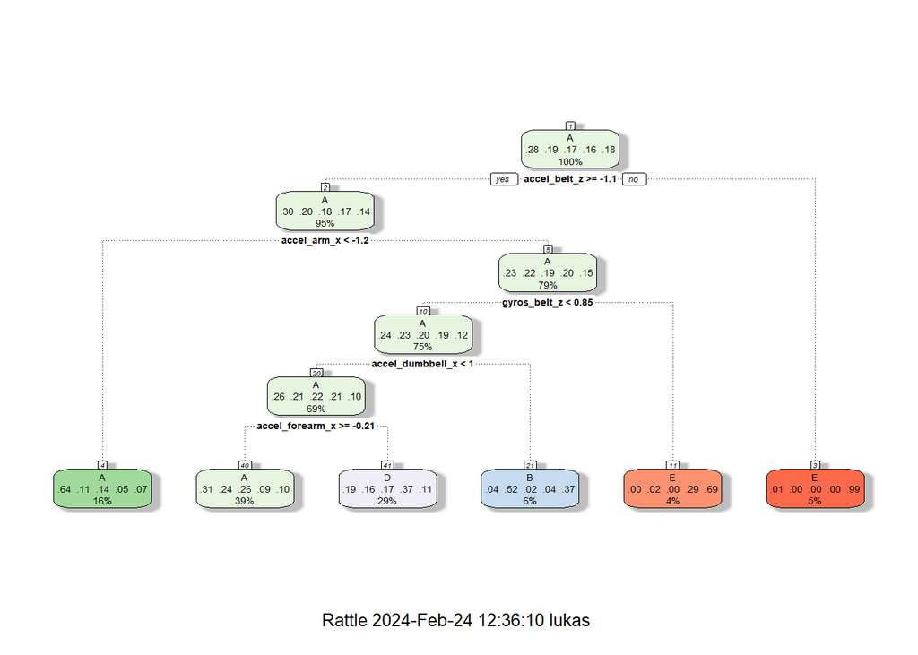

```r
fancyRpartPlot(rpart_GA_model$finalModel)
```

When we take another non-parametric classification model into account however, determination of the classes through k-nearest-neighbors (KNN), our prediction accuracy within the training set dramatically improves.

```r
cl <- makePSOCKcluster(12)
#'assign more CPU cores to this task, decreases computation time
#'massively!
registerDoParallel(cl)
set.seed(73)
knn_GA_model<-train(classe~.,training_GA,
                      method='knn',
                      preProcess=c('center','scale'),
                      trControl=trainControl(method='repeatedcv',repeats = 5),
                      tuneLength=10)

confM<-confusionMatrix(predict(knn_GA_model,training_GA),training_GA$classe)
confM
```

```
Confusion Matrix and Statistics

          Reference
Prediction    A    B    C    D    E
         A 5544   29   19   10    3
         B   10 3745   15    3   19
         C   10   21 3359   41    7
         D   16    1   26 3154   11
         E    0    1    3    8 3567

Overall Statistics

               Accuracy : 0.9871
                 95% CI : (0.9854, 0.9886)
    No Information Rate : 0.2844
    P-Value [Acc > NIR] : < 2.2e-16

                  Kappa : 0.9837

 Mcnemar's Test P-Value : 1.65e-05

Statistics by Class:

                     Class: A Class: B Class: C Class: D Class: E
Sensitivity            0.9935   0.9863   0.9816   0.9807   0.9889
Specificity            0.9957   0.9970   0.9951   0.9967   0.9993
Pos Pred Value         0.9891   0.9876   0.9770   0.9832   0.9966
Neg Pred Value         0.9974   0.9967   0.9961   0.9962   0.9975
Prevalence             0.2844   0.1935   0.1744   0.1639   0.1838
Detection Rate         0.2825   0.1909   0.1712   0.1607   0.1818
Detection Prevalence   0.2856   0.1933   0.1752   0.1635   0.1824
Balanced Accuracy      0.9946   0.9917   0.9884   0.9887   0.9941
```

```r
stopCluster(cl)
```

The model accuracy now amounts to over 98%. Note that the preprocessing by centering and scaling all 24 variables contributed to 3% of that accuracy. Strangely when preprocessing with *knnImpute*, this also denoted a ~3% accuracy improvement as opposed to no preprocessing. This is strange in the sense that *knnImpute* is a means to eliminate NA values by providing the value of its nearest neighbors for that variable. This dataset is however devoid of any NA values.

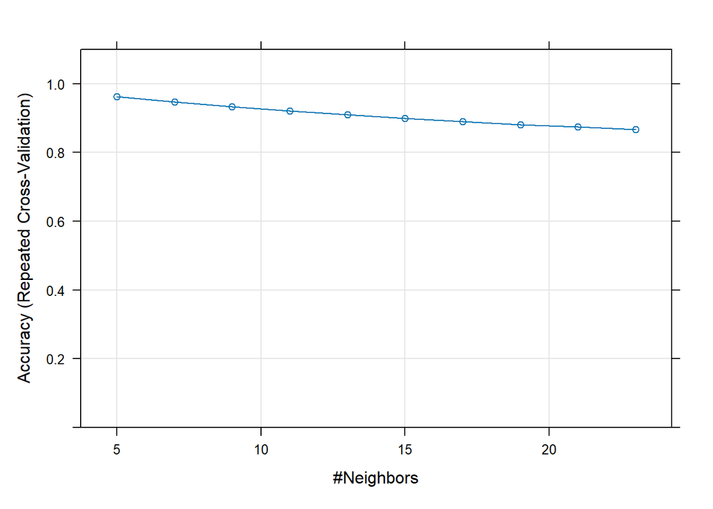

```r
plot(knn_GA_model,ylim=c(0,1.1))
```

The k-value at which the model has this high accuracy is 5. We must however take into account that a lower k-value often coincides with overfitting. Whether that’s an issue at the moment remains to be evaluated. Some accuracy can however be traded for this potential overfitting by moving to a larger *K* and still achieve a good prediction model.

## Prediction of the test data-set

```r
pred_test<-predict(knn_GA_model,testing_GA)
pred_test
```

```
##  [1] B A A A A E D B A A B C B A E E A B B B
## Levels: A B C D E
```

```r
accuracy<-confM$overall[1]

errorfreq<-(1-accuracy)^(-1)

errorfreq<-errorfreq[1]
```

In the training model, the miss classification rate was 1 in 77.6. We do however expect this miss classification rate to be higher in the actual population (i.e. lower accuracy). Given the test data only contained 20 observations, it is hard to predict how many, if any, observations will be miss classified. An actual out of sample error rate could be calculated given a test data set of which the **classe** outcome variable is actually **known**.